# EDUC 452 PS1

2025-04-08 11:29:32.811026

> This homework is due by **Friday, April 18th, 8:00am**. Upload a html file to Canvas called `ps1.html`

> Tip: Questions in red. If a subquestion has no red, no response is needed.

# Question 1 Bernoulli Distribution

Simulations with classic distributions [see distributions_bernoulli.R]: A Bernoulli distribution [https://en.wikipedia.org/wiki/Bernoulli_distribution] is useful when you want to simulate a variable that takes one of two states (e.g., true/false, correct/incorrect, etc); we’ll generically denote these states as 0 and 1. It has one parameter which is the probability of the distribution generating a 1. If we call that parameter p, the probability of the distribution generating a 0 is 1-p so we’ve completely characterized the distribution.

## 1A

The proportion of 1s in a sample turns out to be a decent guess at p (it’s actually the maximum likelihood estimate, but that’s a story for another day!). As with all estimates, you can imagine that the quality of our estimate of p depends upon the sample size.

**Please describe the interplay between the magnitude of p, the sample size, and the resulting quality of the mean as an estimator for p.**

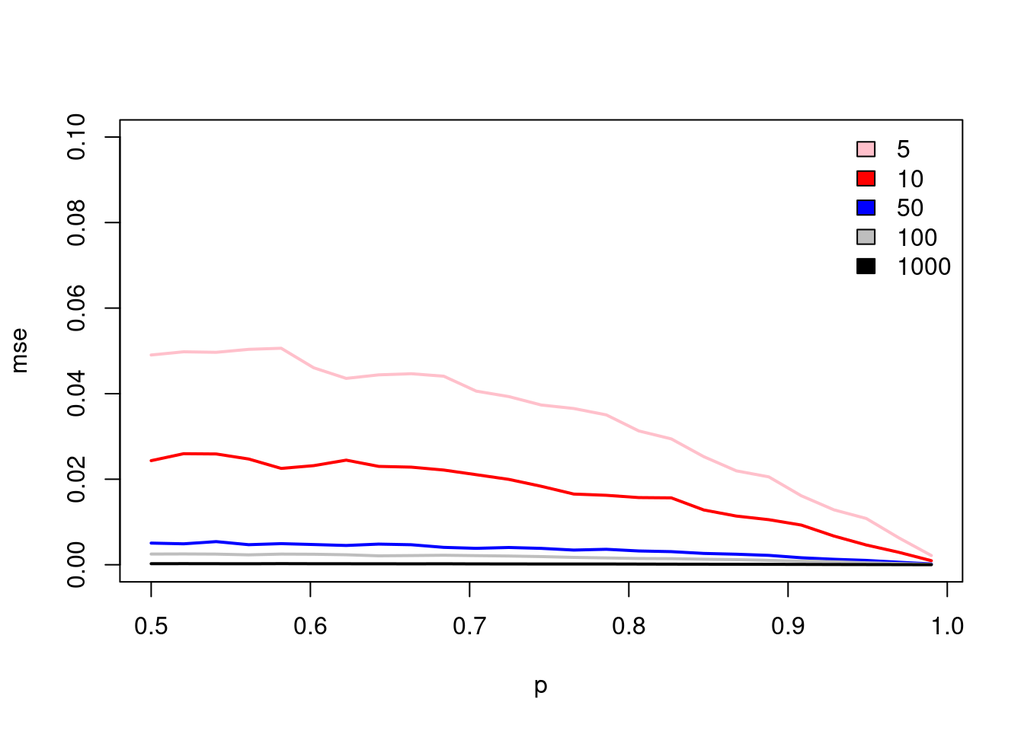

```r
############################################################################################################
##A. bernoulli distribution
##a. how good of an estimate of p is the mean? interplay between the magnitude of p and the sample size

p.est<-list()
for (N in c(5,10,50,100,1000)) {
    for (p in seq(0.5,0.99,length.out=25)) {
        m<-numeric()
        for (i in 1:1000) {
            coins<-rbinom(N,1,p)
            m[i]<-mean(coins)
        }
        p.est[[paste(N,p)]]<-c(N,p,mean((m-p)^2))
    }
}

x<-data.frame(do.call("rbind",p.est))
L<-split(x,x[,1])
cols<-c("pink","red","blue","gray","black")
plot(NULL,ylim=c(0,0.1),xlim=range(x[,2]),xlab='p',ylab='mse')
for (i in 1:length(L)) lines(L[[i]][,-1],lwd=2,col=cols[i])
legend("topright",bty='n',fill=cols,names(L))
```

## 1B

Connection to Binomial distribution: The reason that the R command to simulate data from the Bernoulli distribution is “rbinom” is because the “binomial” distribution (hence binom) is a generalized form of the Bernoulli. The binomial distribution asks how many 1s we get from observing n independent draws from a Bernoulli process with parameter p. Let’s take a look at how we can translate back-and-forth between these two views.

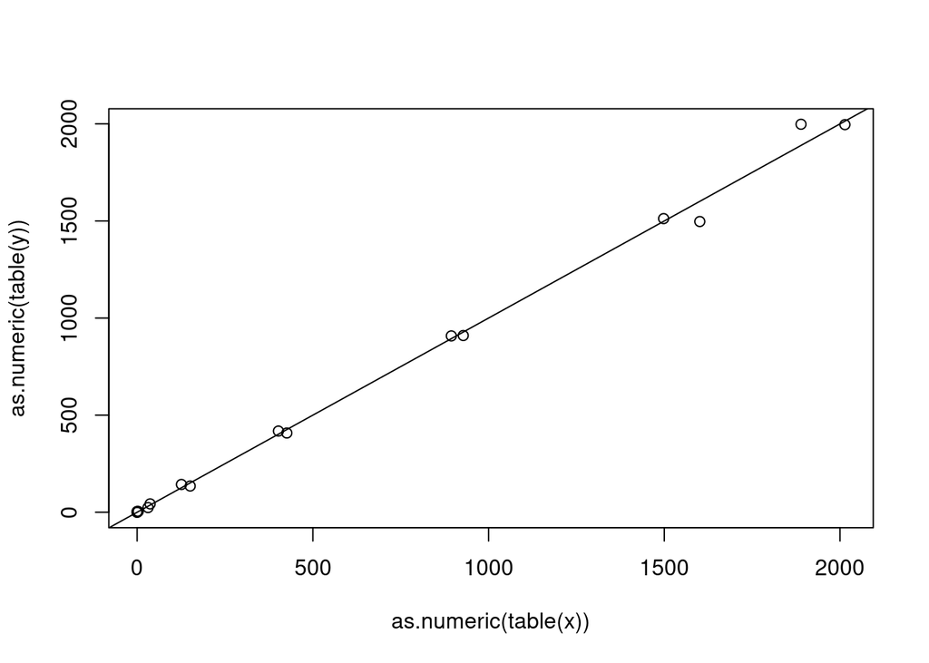

```r
############################################################################################################
##b. the binomial distribution
ntrial<-15
x<-rbinom(10000,ntrial,.5)
y<-numeric()
for (i in 1:10000) {
    z<-numeric()
    for (j in 1:ntrial) z[j]<-rbinom(1,1,.5)
    y[i]<-sum(z)
}
x<-factor(x,levels=0:ntrial)
y<-factor(y,levels=0:ntrial)
plot(as.numeric(table(x)),as.numeric(table(y))); abline(0,1)
```

## 1C

Connection to CLT: The CLT is a wonderfully useful theorem that tells us under what conditions sums of things converge to normal distributions.

**Take a look at the code; which parameter is relevant for applying the CLT? [Note: This is also meant to ensure you’re getting increasingly familiar with a range of distributions!]**

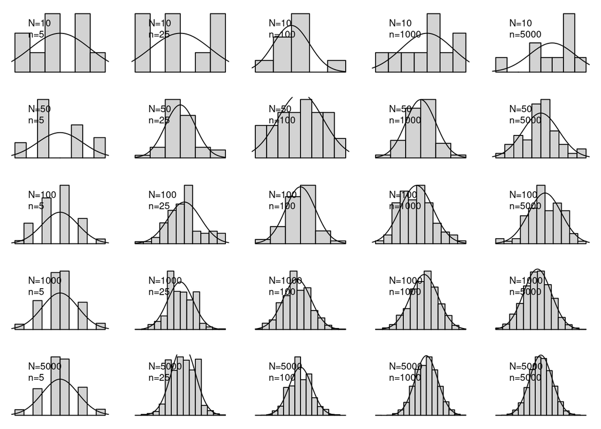

```r
############################################################################################################
##c. the CLT, https://en.wikipedia.org/wiki/Central_limit_theorem
#Which is relevant, N or n, in terms of having the CLT apply?
fun<-function(N,n,p=0.5) { #N is the number of people, n is the number of tosses per person
    x<-rbinom(N,n,p)
    x<-(x-mean(x))/sd(x)
    hist(x,main='',freq=FALSE,yaxt='n',sub='',xaxt='n',yaxt='n')
    xv<-seq(-3,3,length.out=1000)
    lines(xv,dnorm(xv))
    legend("topleft",bty='n',c(paste0("N=",N),paste0("n=",n)))
}
par(mfrow=c(5,5),mar=c(1,1,1,1),mgp=c(2,1,0),oma=rep(0,4))
for (N in c(10,50,100,1000,5000)) for (n in c(5,25,100,1000,5000)) fun(N,n)
```

# Question 2 Normal Distribution

More than any other distribution, we’re going to all become BFF with the normal distribution this quarter. To get started, let’s experiment with a few things.

## 2A Univariate normal distribution

1. Let’s first remind ourselves where the magical value of 1.96 comes from.

```r
##Let's attempt to recover some of the most useful facts about the normal distribution from simulation

##a.i. What proportion of the distribution is more than 1.96 from the mean(=0)?
x<-rnorm(50000,mean=0,sd=1)
sum(abs(x)>1.96)/length(x) #what is this telling us?
```

```
## [1] 0.051
```

2. Suppose x1 has a normal distribution and x2 has a normal distribution (with different mean and variance). **What is the distribution of x1+x2?** We can get an analytical solution to this question, but let’s see how we can also examine this via simulation.

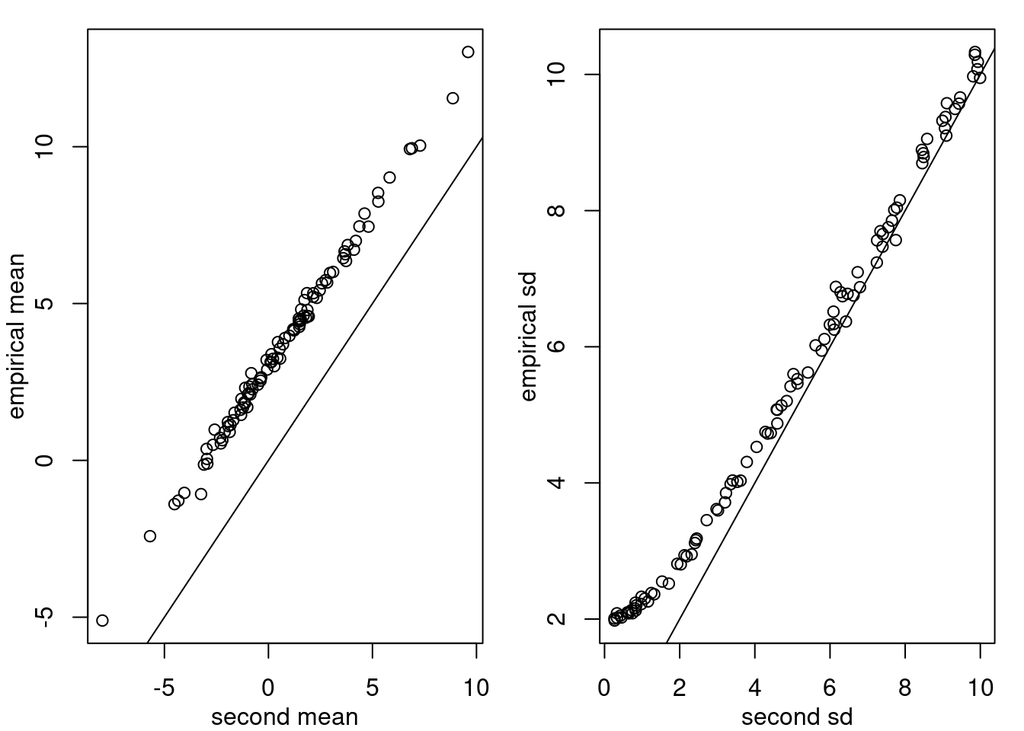

```r
##a.ii What does the sum of two normal variables look like?
N<-1000
m1<-3
sd1<-2
m2<-rnorm(100,mean=0,sd=3)
sd2<-runif(100,0.1,10)
out<-list()
for (i in 1:length(m2)) {
    x1<-rnorm(N,mean=m1,sd=sd1)
    ##
    x2<-rnorm(N,mean=m2[i],sd=sd2[i])
    ##
    y<-x1+x2
    m<-mean(y)
    s<-sd(y)
    out[[i]]<-c(m,s)
}
z<-do.call("rbind",out)

par(mfrow=c(1,2),mgp=c(2,1,0),mar=c(3,3,1,1))
plot(m2,z[,1],xlab="second mean",ylab="empirical mean"); abline(0,1)
plot(sd2,z[,2],xlab="second sd",ylab="empirical sd"); abline(0,1)
```

Note: Analytic derivations of these facts would be preferable for any number of reasons. The goal here is to get our hands dirty with some real simulations but simulations are not always the right tool for the job!